# Bactocap Analysis

This MD incorporates the various analyses I’ve done for the Bactocap project in one place. We are trying to assess the outcome of a targeted sequence capture method described in *this manuscript*. In order to do that, I am measuring ‘success’ of capture in a number of ways, including: the total number of baits captured and sequenced to a give d.o.c, and then assessing the effect of various laboratory metrics on the proportion of baits captured to a given d.o.c. More below.

A note on the programming. I really love R’s tidyverse and plotting capabilities, but I prefer Python for scripting (and almost everything else). The problem was finding a way that I could unify the output of both without running two scripts in parallel that parsed the output of one another/some other hacky and horrible way. I found the `reticulate` library that allows interoperability and the sharing of states between R and Python code, which in turn has allowed me to combine my R and Python scripts into one .Rmd file.

I’m not sure whether it’s horrible or not:

[figure not shown]

But it’s achieved what I want.

I probably could have just written this whole thing in one or the other, but where’s the fun in that?

**Part 1: Calculating the per-sample fraction of the baitset covered to a minimum d.o.c**

```bash
for f in *total.txt #where *.total.txt takes the output files of bedtools genomecov
do
    for i in `seq 0 5 400` #stepwise coverage increments
    do
        echo `awk -v num=$i '$6 < num {print$4}' $f | uniq | wc -l ` `basename $f .total.txt` $i >> covstats.txt
    done
done
```

Then we take that output, add the metadata for each sample set, and calculate the baits captured to min. d.o.c as a fraction of the total for that set

```python
def wrangle(datafile, metadatafile, numbaits):
    colval = pd.Series([len(metadatafile.index) for i in range(len(datafile.index))])
    datafile.insert(loc = 0, column = 'ninds', value = colval)
    datafile['frac'] = (numbaits - (datafile['num_baits']))/numbaits
    datafile['organism'] = np.where(datafile['ninds']==113, 'anthrax', 'mycoplasma')
    return(datafile)
#wrangle from our inputs, then bind together and add organism names
fdf = pd.concat([wrangle(mydata, mymeta, 24444), wrangle(andata, anmeta, 148729)])
```

Here’s the head of the dataframe ‘fdf’ that we produce

```
##    ninds  num_baits        sample  depth      frac    organism
## 0     56          0  07B00774_S16      0  1.000000  mycoplasma
## 1     56      24439  07B00774_S16     10  0.000205  mycoplasma
## 2     56      24444  07B00774_S16     20  0.000000  mycoplasma
## 3     56      24444  07B00774_S16     30  0.000000  mycoplasma
## 4     56      24444  07B00774_S16     40  0.000000  mycoplasma
```

Plot in ggplot2

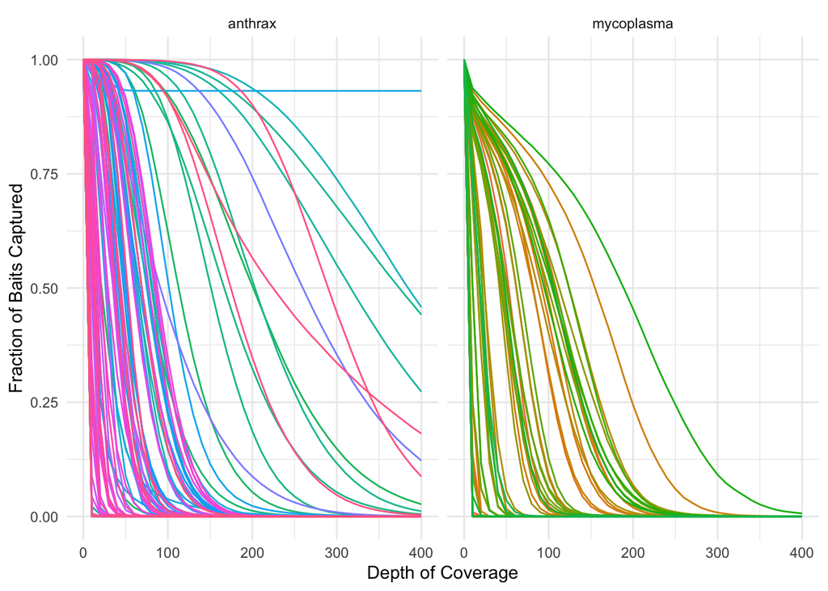

Figure 1. Fraction of baits captured across the whole baitset, to increasing depths of coverage. Line colour denotes individual sample

**Part 2: Calculating the fraction of the sample set with an increasing fraction of the total baitset covered to a minimum d.o.c**

Next, I want to find the number of individuals with a given fraction of baits covered to a given depth of coverage, for both organisms. So I create the cartesian product of: fraction of total baitset (0-1 in 0.1 increments) and minimum depth of coverage over a bait (0 to 400 in increments of 10)

```python
#intialise empty dataframe
size_df = pd.DataFrame(columns=["frac", "coverage", "ninds", "size"])
#Create the cartesian product of these ranges, expand them into a triplet in a for loop and iterate over them all (3-way nested loop)
#the count the number of rows matching each combination of conditions, populating a dataframe with the result
for f, c, i in it.product(np.arange(0.1,1.0,0.1), np.arange(0,410,10),[113, 56]):
    mask = (fdf.frac > f) & (fdf.depth == c) & (fdf.ninds == i)
    size = mask.sum()
    size_df.loc[len(size_df)] = [f, c, i, size]

#get the fraction of individuals per sample set by dividing the number of individuals matching each condition
size_df['frac_inds'] = size_df['size']/size_df['ninds']
#add organism name for ninds as above , based on the number of individuals in each sample set
size_df['organism'] = np.where(size_df['ninds']==113, 'anthrax', 'mycoplasma')
```

Here’s the head of the dataframe ‘size_df’ that we produce

```
##    frac  coverage  ninds  size  frac_inds    organism
## 0   0.1       0.0  113.0  93.0   0.823009     anthrax
## 1   0.1       0.0   56.0  56.0   1.000000  mycoplasma
## 2   0.1      10.0  113.0  78.0   0.690265     anthrax
## 3   0.1      10.0   56.0  43.0   0.767857  mycoplasma
## 4   0.1      20.0  113.0  71.0   0.628319     anthrax
```

Now let’s plot in ggplot2

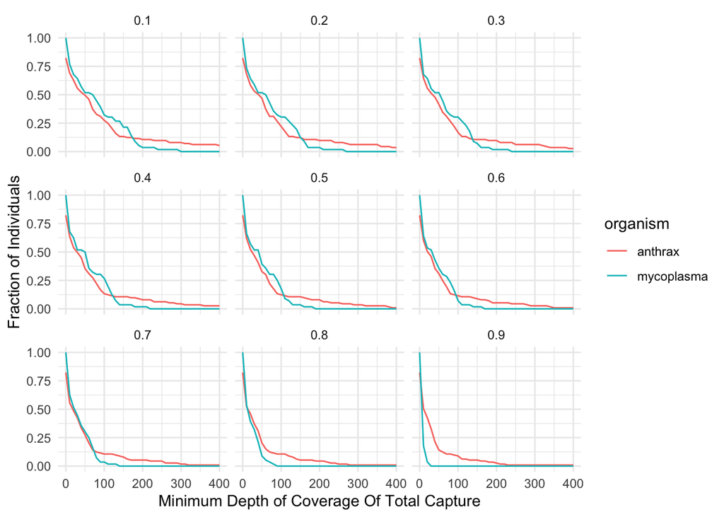

Figure 2. Fraction of individuals in each sampleset that have an increasing fraction of the total baitset (in 10% increments, indicated by the plot’s windows) captured to an increasing d.o.c